# Por definir

### Argumento gráfico

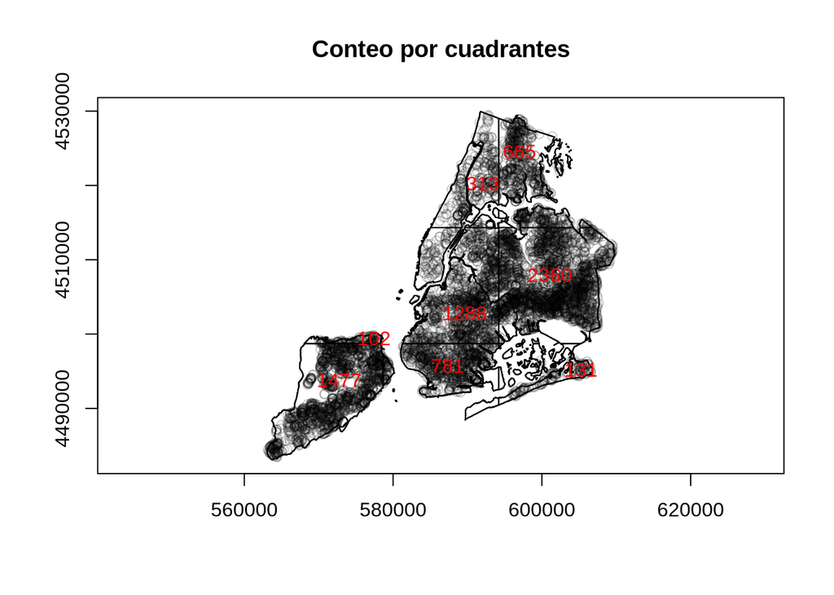

```r
ppp.NY <- readRDS("pppNY.Rds")
qc.NY <- quadratcount(ppp.NY, nx = 3, ny = 3)
plot(ppp.NY, main = "Conteo por cuadrantes",
     axes = T, xaxt = "n", yaxt = "n")
plot(qc.NY, add = T, textargs = list(col = "red"))
```

De allí se puede observar una disparidad grande respecto al número de ocurrencias del proceso en las divisiones generadas sobre la ciudad de Nueva York, donde las zonas de mayor actividad son aquellas cercanas al centro de la ciudad y en Staten Island.

### Argumento inferencial

Posterior al análisis gráfico, se realiza la prueba de bondad de ajuste $\chi^2$ para contrastar el siguiente juego de hipótesis.

$$\begin{cases}
\begin{aligned}
\text{H}_0: &\text{El número de ventas de propiedades por unidad de
area es la misma en todo Nueva York} \\
\text{H}_1: &\text{El número de ventas de propiedades por unidad de
area } \textbf{NO} \text{ es la misma en todo Nueva York}
\end{aligned}
\end{cases}$$

```r
quadrat.test(ppp.NY)
```

```
##
##  Chi-squared test of CSR using quadrat counts
##
## data:  ppp.NY
## X2 = 1088.2, df = 18, p-value < 2.2e-16
## alternative hypothesis: two.sided
##
## Quadrats: 19 tiles (irregular windows)
```

De allí se obtuvo un valor p del orden de $10^{-16}$ por lo que realmente hay un rechazo condundente por parte del test hacia la hipótesis de homogeneidad en el proceso y por tanto se está ante un proceso Poisson inhomogéneo.

# Estimación de la intensidad via Kernel

# Modelos log-lineales para la intensidad

# Propiedades de segundo orden